# Lecture 17 - ARIMA Forecasting

## Effect of Taking Log (1)

- Taking a log makes all price movement into relative to the current price.
- For example, 10% increase from 10 is 11. Change of +1.
- 10% increase from 50 is 55. Change of +5.
- If you take a log, then log(10) to log(11) has
  $$log(11) - log(10) = log(11/10) = log(1.1) = 0.0953$$
- On the other hand,
  $$log(55) - log(50) = log(55/50) = log(1.1) = 0.0953$$

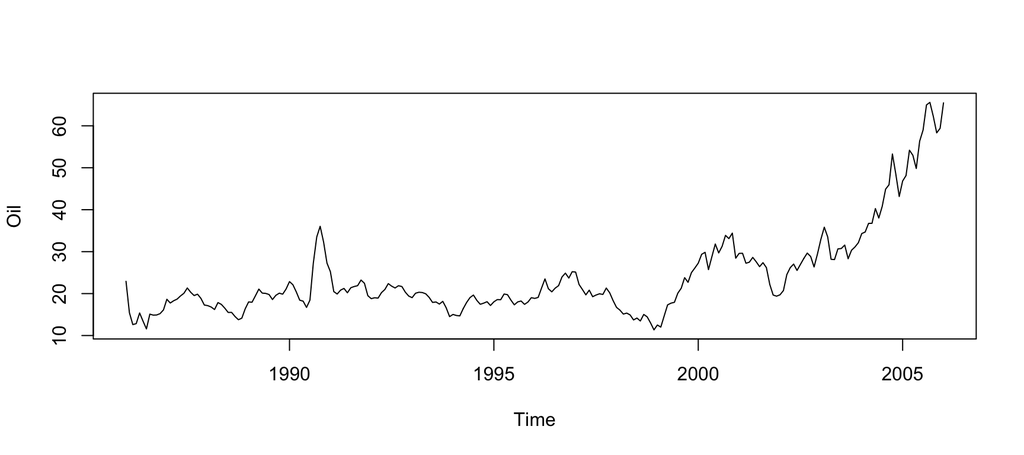

```r
plot(Oil)
```

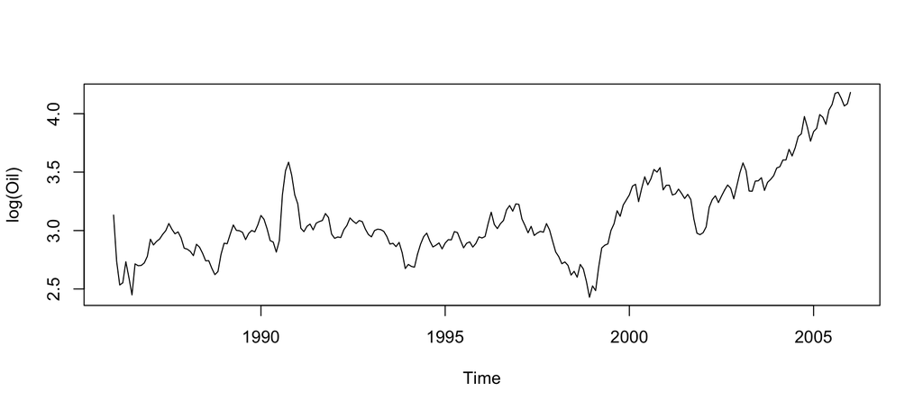

```r
plot(log(Oil))
```

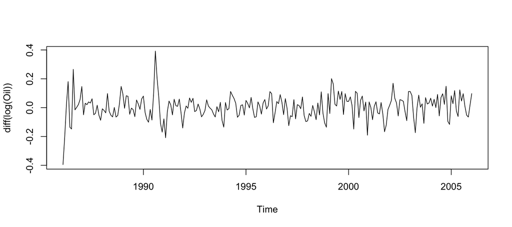

```r
plot(diff(log(Oil)))
```

## Effect of Taking Log(2)

- Classical Decomposition
  $$Y_t = T_t + S_t + X_t$$
  where $T_t$ is a trend, $S_t$ is a seasonality, $X_t$ is a stationarty series.
- Multiplicative Model
  $$Y_t = (T_t)(S_t)(X_t)$$
- If you take a log,
  $$log(Y_t) = log(T_t) + log(S_t) + log(X_t)$$